# House Prices, Property Taxes and Municipal Bond Yields

[output not shown]

# 1 Summary

- Property tax is a large fraction of the total revenue
- House prices have a significant impact on property assesments, property tax rate and property tax amounts
- Mean foreclosure rate and house price index significantly impact municipal bond yields
- Effects of foreclosure rate and house price index are stronger when share of property tax in revenue is larger

# 2 Data

3 Datasets were constructed.

1. Issuer data contains financial information on each issuer
2. Issue data has information about each issue and their trading data
3. Household level data has information about annual property tax amounts and assesment values for individual houses.

## 2.1 Issuer Data

- Issure financial data was obtained from bloomberg for the selected 5275 issuers who are categorized as “Municipal-City” by Bloomberg
- Available data include Total Revenue, Total property tax revenue, Total Assets and Leverage.

## 2.2 Bond Data

- This dataset contians origination and trading information for bonds issued by the above 5275 issuers.
- This data contains information such as issued date, issue type (GO vs Revenue), issue purpose, offering type, wheather taxable by state, wheather subject to federal tax, whether bond is callable, maturity date, trade date and yield
- The code used to generate this dataset is available at https://github.com/dimuthu999/muni/blob/master/data%20merge.R

## 2.3 Household Level Data

Back to top

# 3 Descriptive Statistics

## 3.1 Issuer Financials

- Mean (Median) revenue is 21 (8) million USD
- 50% of the revenue is from property taxes
- Liabilities is 30% of total assets

```
## [1] "Number of Municipalties :  5275"
```

```
## [1] "Number of States :  49"
```

```
## [1] "Total revenues of the general fund ($ millions)"
```

```
##     Min.  1st Qu.   Median     Mean  3rd Qu.     Max.
##   0.0303   2.2990   7.9310  20.9900  24.3500 217.8000
```

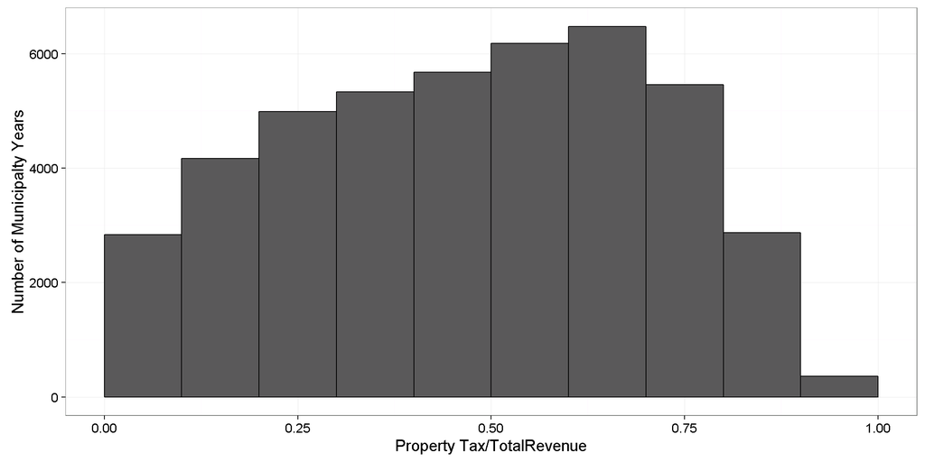

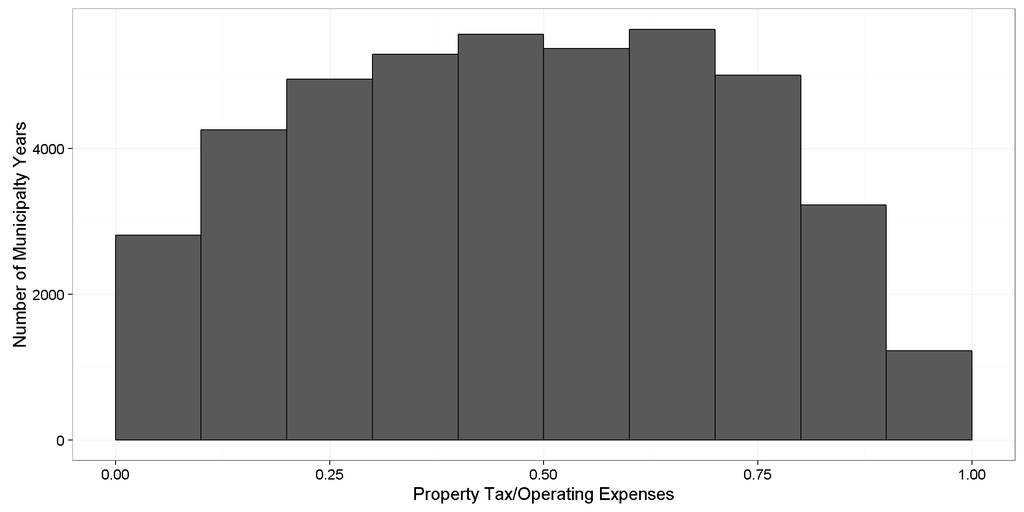

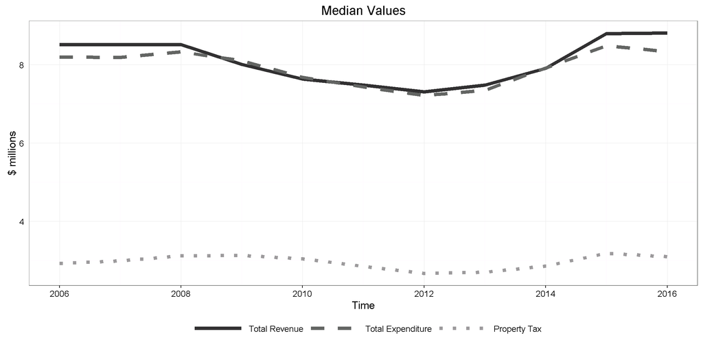

```
## [1] "return_3yr_1 = 3 year return on house price index lagged by 1 year"
```

```
##
## ==============================================================================
## Statistic                      Mean   St. Dev. Pctl(25) Median Pctl(75)   N
## ------------------------------------------------------------------------------
## return_3yr_1                   0.007   0.052    -0.023  0.004   0.035   44,345
## return_1yr_1                   0.004   0.056    -0.026  0.002   0.030   44,345
## proptax_totaltax               0.471   0.232    0.283   0.486   0.661   44,345
## proptax_opex                   0.498   0.288    0.283   0.488   0.689   44,345
## exp_revenue                    0.992   0.240    0.901   0.973   1.041   44,345
## cash_liabilities              Inf.000           1.117   2.758   6.612   38,663
## liabilities_assets             0.293   0.239    0.099   0.216   0.443   38,187
## principal_debt_service_reveue  0.051   0.091    0.009   0.032   0.066   22,977
## ------------------------------------------------------------------------------
```

Back to top

## 3.2 Bond Level Trading Data

```
##
## ===================================================================
## Statistic         Mean  St. Dev. Pctl(25) Median Pctl(75)     N
## -------------------------------------------------------------------
## YIELD             3.074  1.822    2.000   3.250   4.040   3,497,806
## yield_minus_tbill 2.008  2.162    0.690   1.994   3.302   3,497,806
## forc_pct          0.001  0.001    0.0003  0.0005  0.001   4,170,835
## -------------------------------------------------------------------
```

```
## [1] "Insurance Status"
```

```
##
##      N      Y
## 204604  94887
```

```
## [1] "Callable"
```

```
##
##      N      Y
## 282032  17459
```

```
## [1] "Issue Type"
```

```
##
##   general obligation limited general obligation unlimited
##                        86516                       182880
##                        other
##                        30095
```

Back to top

## 3.3 House Level Property Tax Data

- Tax rate is negatively related to 1 year lagged 3-digit zip code level house price index
- Assesed Value is positively related to 1 year lagged 3-digit zip code level house price index
- Tax amount is positively related to 1 year lagged 3-digit zip code level house price index

```
## [1] "Number of Houses :  46751"
```

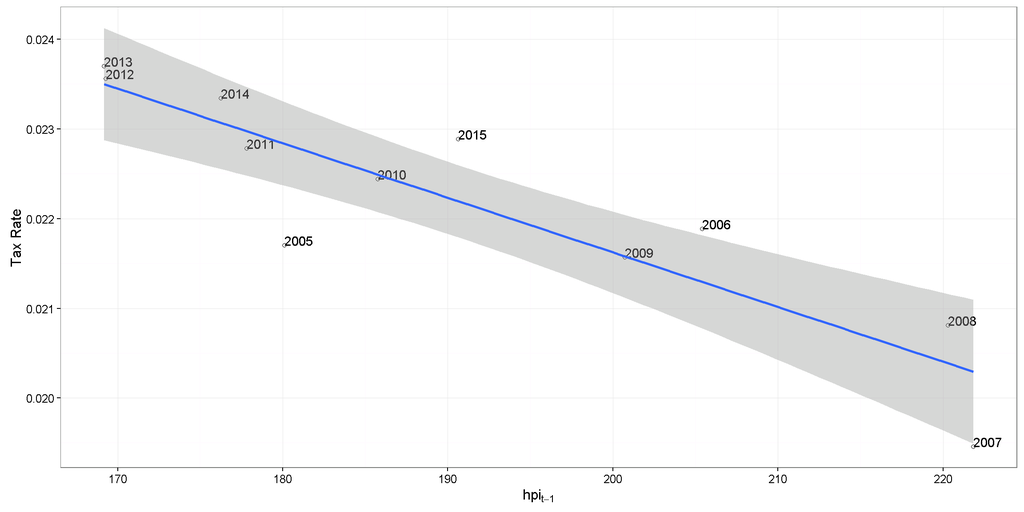

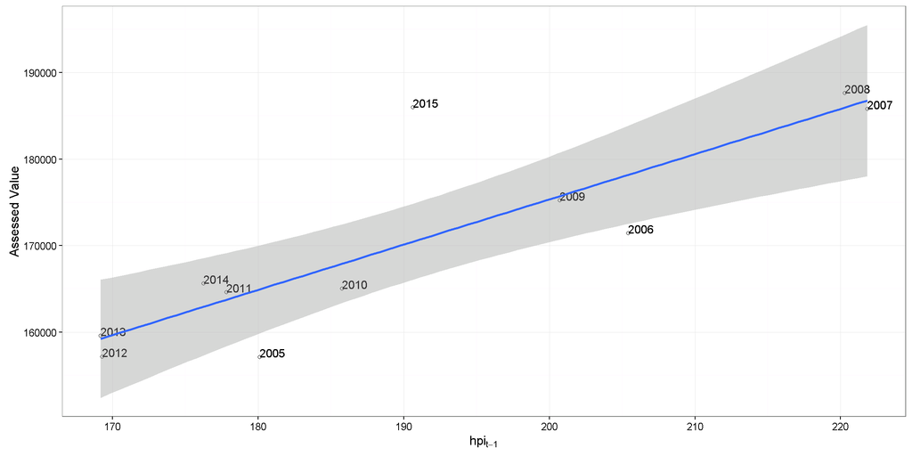

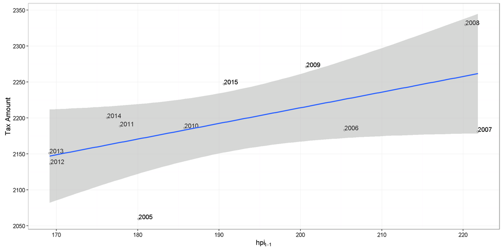

```
##
## Regressions on lagged HPI
## ==================================================================
##                                       Dependent variable:
##                              -------------------------------------
##                               tax_pct     assesment    tax_amount
##                                 (1)          (2)          (3)
## ------------------------------------------------------------------
## hpi                          -0.0001***  522.877***      2.177*
##                              (0.00001)    (107.371)     (1.022)
## Constant                      0.034***  70,773.120*** 1,778.737***
##                               (0.002)   (20,563.440)   (195.667)
## ------------------------------------------------------------------
## Observations                     11          11            11
## R2                             0.809        0.725        0.335
## Adjusted R2                    0.788        0.694        0.262
## Residual Std. Error (df = 9)   0.001      6,438.219      61.262
## F Statistic (df = 1; 9)      38.208***    23.715***      4.542*
## ==================================================================
## Note:                                  *p<0.1; **p<0.05; ***p<0.01
```

```
##
## Correlations
## ==============================================================================================================
##                   tax_pct_assesment tax_value tax_amount tax_pct_change return_1yr_1 return_2yr_1 return_3yr_1
## --------------------------------------------------------------------------------------------------------------
## tax_pct_assesment         1          -0.014     0.925        0.956         -0.001       -0.001       0.0001
## tax_value              -0.014           1       0.093        -0.002        0.015        0.024        0.030
## tax_amount              0.925         0.093       1          0.968        -0.0003       0.0002       0.001
## tax_pct_change          0.956        -0.002     0.968          1           0.0004       0.0003       0.0003
## return_1yr_1           -0.001         0.015    -0.0003       0.0004          1          0.933        0.786
## return_2yr_1           -0.001         0.024     0.0002       0.0003        0.933          1          0.943
## return_3yr_1           0.0001         0.030     0.001        0.0003        0.786        0.943          1
## --------------------------------------------------------------------------------------------------------------
```

Back to top

# 4 Results

> All of the following regressions are fixed effect models. Depending on the specification bond, issuer or house fixed effects were used.
- main variable of interest : “return-3yr-1”" is 1 year lagged 3 year return on the house price index of the zip code

## 4.1 Municipalty Level: Property tax on Lagged House Price Returns

```
## These series are NA and have been removed: BS_ST_BORROW, BS_TOT_LOAN, BS_ST_DEBT
## This series is constant and has been removed: INDUSTRY_SUBGROUP
```

```
##
## Change in Property Tax Revenue
## ====================================================================
##                                          Dependent variable:
##                                   ----------------------------------
##                                              ols_formula
##                                   All HPI  Negative HPI Positive HPI
##                                     (1)        (2)          (3)
## --------------------------------------------------------------------
## return_3yr_1                      0.199***   0.483***      0.100
##                                   (0.048)    (0.118)      (0.109)
## --------------------------------------------------------------------
## Fixed Effects                      Issuer     Issuer       Issuer
## mfx: impact of 1sd as pct of mean  33.73      81.97        16.93
## Observations                       44,328     20,259       24,069
## Adjusted R2                        -0.132     -0.289       -0.265
## ====================================================================
## Note:                                    *p<0.1; **p<0.05; ***p<0.01
```

```
##
## Change in Other Tax Revenues
## ===================================================================
##                                          Dependent variable:
##                                   ---------------------------------
##                                              ols_formula
##                                   All HPI Negative HPI Positive HPI
##                                     (1)       (2)          (3)
## -------------------------------------------------------------------
## return_3yr_1                      -0.021     -0.060      0.263***
##                                   (0.030)   (0.092)      (0.077)
## -------------------------------------------------------------------
## Fixed Effects                     Issuer     Issuer       Issuer
## mfx: impact of 1sd as pct of mean
## Observations                      39,057     19,750       19,307
## Adjusted R2                       -0.152     -0.294       -0.340
## ===================================================================
## Note:                                   *p<0.1; **p<0.05; ***p<0.01
```

```
##
## Change in Property Tax/Revenue
## =====================================================================
##                                           Dependent variable:
##                                   -----------------------------------
##                                               ols_formula
##                                    All HPI  Negative HPI Positive HPI
##                                      (1)        (2)          (3)
## ---------------------------------------------------------------------
## return_3yr_1                      14.545***    -0.214     42.865***
##                                    (4.423)    (0.621)      (12.943)
## ---------------------------------------------------------------------
## Fixed Effects                      Issuer      Issuer       Issuer
## mfx: impact of 1sd as pct of mean   215.3      -3.17        634.51
## Observations                       44,328      20,259       24,069
## Adjusted R2                        -0.135      -0.291       -0.266
## =====================================================================
## Note:                                     *p<0.1; **p<0.05; ***p<0.01
```

```
##
## Change in Property Tax/OPEX
## ====================================================================
##                                          Dependent variable:
##                                   ----------------------------------
##                                              ols_formula
##                                   All HPI  Negative HPI Positive HPI
##                                     (1)        (2)          (3)
## --------------------------------------------------------------------
## return_3yr_1                      0.151***    0.164        0.147
##                                   (0.035)    (0.103)      (0.093)
## --------------------------------------------------------------------
## Fixed Effects                      Issuer     Issuer       Issuer
## mfx: impact of 1sd as pct of mean  153.14     165.99       149.25
## Observations                       39,056     19,750       19,306
## Adjusted R2                        -0.152     -0.294       -0.340
## ====================================================================
## Note:                                    *p<0.1; **p<0.05; ***p<0.01
```

Back to top

## 4.2 House Level: Property tax on Lagged House Price Returns

```
##
## All HPI Returns
## =======================================================================
##                                            Dependent variable:
##                                   -------------------------------------
##                                                ols_formula
##                                   Chg. in Rate Chg. in Asmt Chg. in Amt
##                                       (1)          (2)          (3)
## -----------------------------------------------------------------------
## return_3yr_1                         0.003       0.662***    0.394***
##                                     (0.040)      (0.006)      (0.008)
## -----------------------------------------------------------------------
## Fixed Effects                        House        House        House
## mfx: impact of 1sd as pct of mean     1.67        175.26       0.82
## Observations                        370,706      370,706      370,706
## Adjusted R2                          -0.137       -0.098      -0.128
## =======================================================================
## Note:                                       *p<0.1; **p<0.05; ***p<0.01
```

```
##
## Only Negative HPI Returns
## =======================================================================
##                                            Dependent variable:
##                                   -------------------------------------
##                                                ols_formula
##                                   Chg. in Rate Chg. in Asmt Chg. in Amt
##                                       (1)          (2)          (3)
## -----------------------------------------------------------------------
## return_3yr_1                        -0.024*      0.862***    0.516***
##                                     (0.013)      (0.022)      (0.028)
## -----------------------------------------------------------------------
## Fixed Effects                        House        House        House
## mfx: impact of 1sd as pct of mean    -15.8        228.22       1.08
## Observations                        174,870      174,870      174,870
## Adjusted R2                          -0.308       -0.293      -0.304
## =======================================================================
## Note:                                       *p<0.1; **p<0.05; ***p<0.01
```

```
##
## Only Positive HPI Returns
## =======================================================================
##                                            Dependent variable:
##                                   -------------------------------------
##                                                ols_formula
##                                   Chg. in Rate Chg. in Asmt Chg. in Amt
##                                       (1)          (2)          (3)
## -----------------------------------------------------------------------
## return_3yr_1                         -0.053      0.594***    0.213***
##                                     (0.125)      (0.015)      (0.022)
## -----------------------------------------------------------------------
## Fixed Effects                        House        House        House
## mfx: impact of 1sd as pct of mean    -34.04       157.46       0.45
## Observations                        195,836      195,836      195,836
## Adjusted R2                          -0.277       -0.265      -0.276
## =======================================================================
## Note:                                       *p<0.1; **p<0.05; ***p<0.01
```

Back to top

## 4.3 Yield Regression

- Dependent Variable: Yield - 3 month t-bill rate
- forc_pct: monthly zipcode level mean foreclosure rate
- high-proptax-totaltax : Property tax/Total Tax greater than median
- high-liabilities-assets : Liabilities/Assets greater than median
- high-exp-revenue: Expenditure/Revenue greater than median
- high-principal-debt-service-revenue: Principal debt servicer/Revenue greater than median

[output not shown]

```
## This series is constant and has been removed: general_obligation
```

[output not shown]

```
##
## ==============================================================================
##                                                Dependent variable:
##                                    -------------------------------------------
##                                                    ols_formula
##                                       (1)        (2)        (3)        (4)
## ------------------------------------------------------------------------------
## forc_pct                           46.889***  25.283***
##                                     (3.006)    (4.846)
## high_proptax_totaltax                          0.058***              0.047***
##                                                (0.009)               (0.009)
## high_liabilities_assets                       -0.023***             -0.020***
##                                                (0.006)               (0.006)
## high_principal_debt_service_reveue             0.028***              0.030***
##                                                (0.008)               (0.008)
## forc_pct_1                                               10.832***  -12.786**
##                                                           (3.154)    (5.087)
## forc_pct:high_proptax_totaltax                25.406***
##                                                (7.624)
## forc_pct_1:high_proptax_totaltax                                    51.432***
##                                                                      (7.817)
## ------------------------------------------------------------------------------
## Fixed Effects                      Bond, Year Bond, Year Bond, Year Bond, Year
## Observations                       1,288,031   701,540   1,272,610   687,966
## Adjusted R2                          0.341      0.335      0.338      0.327
## ==============================================================================
## Note:                                              *p<0.1; **p<0.05; ***p<0.01
```

```
##
## ===============================================================
##                                        Dependent variable:
##                                    ----------------------------
##                                            ols_formula
##                                         (1)            (2)
## ---------------------------------------------------------------
## hpi_1                                -0.001***      0.001***
##                                       (0.0001)      (0.0002)
## high_proptax_totaltax                               0.313***
##                                                      (0.032)
## high_liabilities_assets                             -0.019***
##                                                      (0.005)
## high_principal_debt_service_reveue                  0.034***
##                                                      (0.008)
## hpi_1:high_proptax_totaltax                         -0.001***
##                                                     (0.0002)
## ---------------------------------------------------------------
## Fixed Effects                        Bond, Year    Bond, Year
## Observations                         1,396,589       764,666
## Adjusted R2                            0.343          0.341
## ===============================================================
## Note:                               *p<0.1; **p<0.05; ***p<0.01
```

Back to top